# 550 Project

Xiuran Lin

2022-12-04

# **Introduction**

## My dataset is about stroke prediction. According to the World Health Organization (WHO) stroke is the 2nd leading cause of death globally, responsible for approximately 11% of total deaths. I am going to summarize the data with some descriptive analysis including tables and figures to show the possible difference or correlation from the data.

# **Attribute Information**

## 1) id: unique identifier

## 2) gender: “Male”, “Female” or “Other”

## 3) age: age of the patient

## 4) hypertension: 0 if the patient doesn’t have hypertension, 1 if the patient has hypertension

## 5) heart_disease: 0 if the patient doesn’t have any heart diseases, 1 if the patient has a heart disease

## 6) ever_married: “No” or “Yes”

## 7) work_type: “children”, “Govt_jov”, “Never_worked”, “Private” or “Self-employed”

## 8) Residence_type: “Rural” or “Urban”

## 9) avg_glucose_level: average glucose level in blood

## 10) bmi: body mass index

## 11) smoking_status: “formerly smoked”, “never smoked”, “smokes” or “Unknown”*

## 12) stroke: 1 if the patient had a stroke or 0 if not

## *Note: “Unknown” in smoking_status means that the information is unavailable for this patient

# **Read data set**

```r
here::i_am("550_project_report_Xiuran_Lin.Rmd")
 data <- readRDS(
   file = here::here("output/data_clean.rds")
 )
```

# **Table**

#### This table showed BMI level and average glucose level for different work type among study participants.

```r
library(gtsummary)

table_one <- readRDS(
  file = here::here("output/table_one.rds")
)
table_one
```

| **Characteristic** | **Overall**, N = 5,110<sup>1</sup> | **BMI Level in different types of work** **healthyweight**, N = 1,258<sup>1</sup> | **BMI Level in different types of work** **obesity**, N = 2,094<sup>1</sup> | **overweight**, N = 1,409<sup>1</sup> | **underweight**, N = 349<sup>1</sup> |  |  |
| --- | --- | --- | --- | --- | --- | --- | --- |
| work_type |  |  |  |  |  |  |  |
| children | 687 (13%) | 291 (23%) | 46 (2.2%) | 51 (3.6%) | 299 (86%) |  |  |
| Govt_job | 657 (13%) | 140 (11%) | 315 (15%) | 199 (14%) | 3 (0.9%) |  |  |
| Never_worked | 22 (0.4%) | 10 (0.8%) | 5 (0.2%) | 5 (0.4%) | 2 (0.6%) |  |  |
| Private | 2,925 (57%) | 654 (52%) | 1,340 (64%) | 893 (63%) | 38 (11%) |  |  |
| Self-employed | 819 (16%) | 163 (13%) | 388 (19%) | 261 (19%) | 7 (2.0%) |  |  |
| avg_glucose_level | 92 (77, 114) | 90 (75, 109) | 94 (79, 130) | 91 (76, 112) | 88 (76, 107) |  |  |

<sup>1</sup> n (%); Median (IQR)

# **Graph Analysis**

#### This is the mosaic plot to show the difference of bmi level between people who have married and people who have not married.

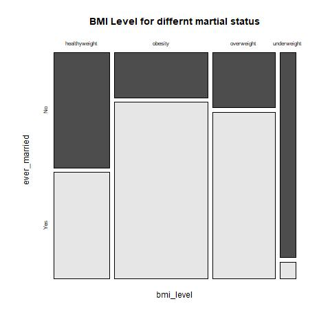

```r
library(ggplot2)

knitr::include_graphics(
  here::here("output/mosaicplot.png")
)
```